# Project-IE360

Group_18

6/13/2020

# Introduction

Trendyol is a leading online retailer where you can purchase products in numerous categories.

In the project we have 8 products in different categories. We have the information of price, number of sales, number of page visits, number of people who favored , number of people have it in basket, total number of sales in the category and the total number of sales of the brand in the same category data for all 8 products.

# Solution Steps

### Data

For every product, we seperate the dataset. Afterwards we check the dataset to eliminate the dates when the product is not on sale. After cleaning the data, we plot the sales number of the product and its Auto - Correlation graph to see its behaviour.

Trendyol does some special sale days such as black friday. In these sale days, the number of sales become outliers. Also before and after these days mostly their number of sales decrease. To have a smoothened data we used averaging for those days. The number of sales in outlier days are transformed into the mean of their neighbors.

### Building Forecasting Models

Our models are based on linear regression and arima. We have 8 different products from 8 different categories. For linear regression models, we consider the possible effects by products and try to include these effects. For Arima Models, we check its Auto Correlation function to guess the Arima parameters. We also consider the auto arima model found by R.

### Validation of The Models

For every data we have, we chose our model by confirming its validity. For that we used time series cross validation from 1 to 50 days. And we used the model which shows smallest Mean Absolute Error (MAE).

# Forecasting Models for Products

## Product 1

#### Leggings

This product is used by high number of women every day. Its sales is not expected to be affected by seasons. So now we check its plot.

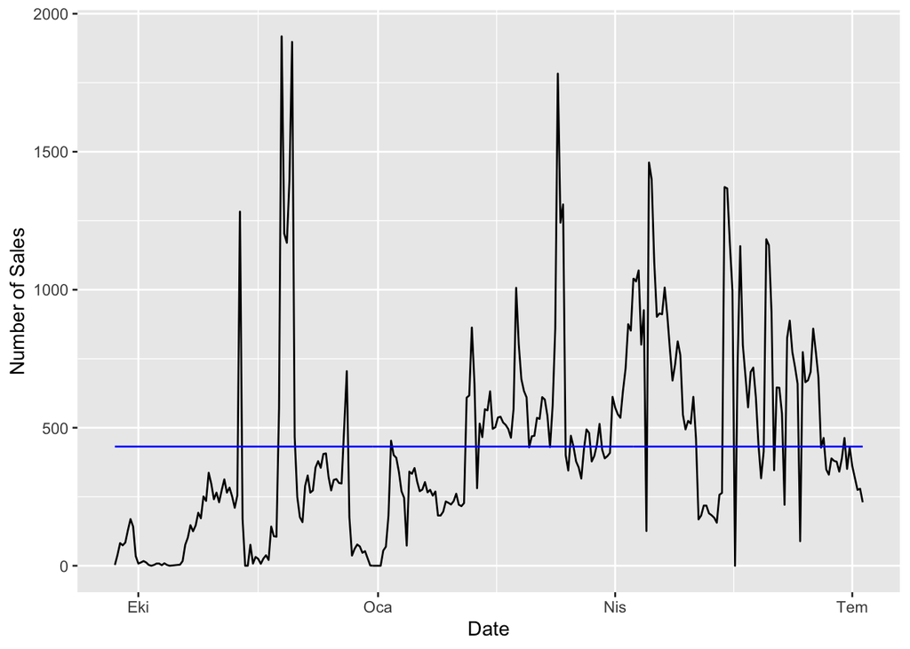

*Graph 1: Number of Sales over Time of Product 1*

There seems a peak at around November. This is when the black friday discount happens. The Blue Line is the Mean of the sales. It is visible that after and before the discount, the sales seems to go lower than average.

Now we check the Auto-Correlation Graph of the data.

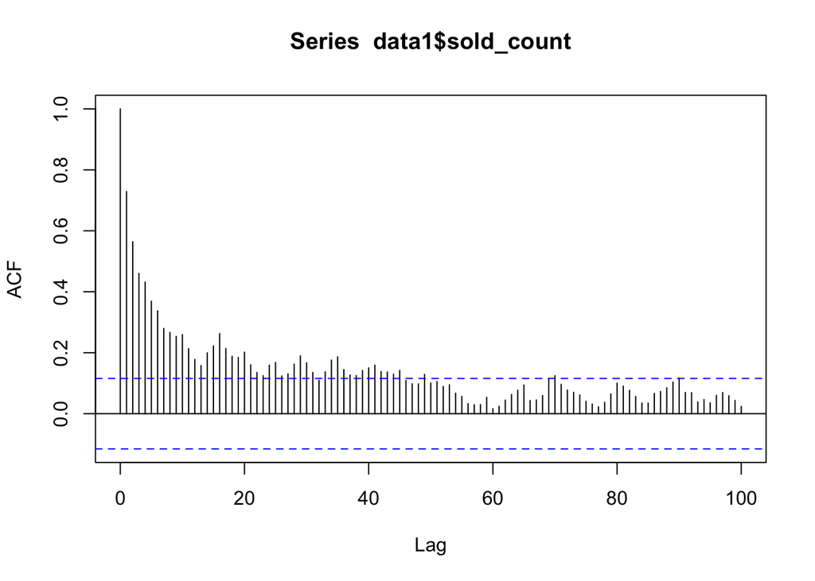

*Graph 2: Auto-Correlation Graph of the Number of Sales over Time of Product 1*

The neighbouring days have a high correlation over time. This is a sign of trend. There seems no seasonality.

Now we will create an alternative dataset where the outlier days is smoothened. We will use both the original and the alternative datasets while building our models.

```r
data1_alt <- data1
data1_alt$sold_count[40:80] <- mean(data1$sold_count[30:90])
```

#### Linear Regression Model

We start with using every possible parameter in the model.

```
##
## Call:
## lm(formula = sold_count ~ visit_count + favored_count + category_sold +
##     basket_count + price + category_brand_sold + category_visits,
##     data = data1)
##
## Residuals:
##     Min      1Q  Median      3Q     Max
## -613.96  -67.90  -17.78   53.38 1205.11
##
## Coefficients:
##                       Estimate Std. Error t value Pr(>|t|)
## (Intercept)          7.635e+00  5.594e+01   0.136   0.8915
## visit_count          1.199e-02  1.788e-03   6.704 1.11e-10 ***
## favored_count        8.038e-02  4.227e-02   1.902   0.0582 .
## category_sold        1.837e-02  1.639e-02   1.121   0.2632
## basket_count         1.162e-01  1.016e-02  11.438  < 2e-16 ***
## price               -2.057e-01  1.454e+00  -0.142   0.8876
## category_brand_sold -8.267e-02  7.273e-02  -1.137   0.2566
## category_visits     -2.818e-04  4.927e-05  -5.720 2.73e-08 ***
## ---
## Signif. codes:  0 '***' 0.001 '**' 0.01 '*' 0.05 '.' 0.1 ' ' 1
##
## Residual standard error: 170 on 280 degrees of freedom
## Multiple R-squared:  0.7807, Adjusted R-squared:  0.7752
## F-statistic: 142.4 on 7 and 280 DF,  p-value: < 2.2e-16
```

There seems to exist insignificant attributes.

Now we calculate the Akaike Information Criteria.

```
## [1] 3785.425
```

After several steps to eliminate the insignificant attributes, our final linear regression model is:

```
##
## Call:
## lm(formula = sold_count ~ visit_count + favored_count + basket_count +
##     category_visits, data = data1)
##
## Residuals:
##     Min      1Q  Median      3Q     Max
## -624.53  -71.61  -14.72   47.65 1223.09
##
## Coefficients:
##                   Estimate Std. Error t value Pr(>|t|)
## (Intercept)      9.932e+00  1.918e+01   0.518   0.6049
## visit_count      1.220e-02  1.581e-03   7.715 2.08e-13 ***
## favored_count    8.148e-02  3.724e-02   2.188   0.0295 *
## basket_count     1.114e-01  8.834e-03  12.607  < 2e-16 ***
## category_visits -2.587e-04  4.342e-05  -5.958 7.58e-09 ***
## ---
## Signif. codes:  0 '***' 0.001 '**' 0.01 '*' 0.05 '.' 0.1 ' ' 1
##
## Residual standard error: 169.5 on 283 degrees of freedom
## Multiple R-squared:  0.7797, Adjusted R-squared:  0.7765
## F-statistic: 250.3 on 4 and 283 DF,  p-value: < 2.2e-16
```

It has a relatively hig R^2 with 0.78.

Now we check its Akaike Information Criteria value.

```
## [1] 3780.83
```

We implied similiar steps to the alternative data. Our best model with the alternative data is:

```
##
## Call:
## lm(formula = sold_count ~ visit_count + favored_count + category_sold +
##     basket_count + category_brand_sold + category_visits, data = data1_alt)
##
## Residuals:
##     Min      1Q  Median      3Q     Max
## -333.33  -92.71  -11.02   85.76  386.13
##
## Coefficients:
##                       Estimate Std. Error t value Pr(>|t|)
## (Intercept)          1.277e+02  1.518e+01   8.412 2.07e-15 ***
## visit_count          4.124e-03  1.259e-03   3.275  0.00119 **
## favored_count        6.841e-02  2.970e-02   2.303  0.02199 *
## category_sold       -2.099e-02  1.154e-02  -1.819  0.07001 .
## basket_count         1.285e-01  7.063e-03  18.199  < 2e-16 ***
## category_brand_sold  9.401e-02  5.095e-02   1.845  0.06609 .
## category_visits     -1.659e-04  3.420e-05  -4.851 2.03e-06 ***
## ---
## Signif. codes:  0 '***' 0.001 '**' 0.01 '*' 0.05 '.' 0.1 ' ' 1
##
## Residual standard error: 119.9 on 281 degrees of freedom
## Multiple R-squared:  0.8524, Adjusted R-squared:  0.8492
## F-statistic: 270.4 on 6 and 281 DF,  p-value: < 2.2e-16
```

It has a higher R^2 value than the original dataset. But now more attributes seems significant.

Now we check its Akaike Information Criteria value.

```
## [1] 3583.427
```

#### ARIMA model

We used 2 arima models, one by automated function auto.arima and one by trial.

The ARIMA model generated by auto.arima function:

```
## Series: data1$sold_count
## ARIMA(1,1,1)
##
## Coefficients:
##          ar1      ma1
##       0.6275  -0.9584
## s.e.  0.0567   0.0233
##
## sigma^2 estimated as 58761:  log likelihood=-1982.62
## AIC=3971.25   AICc=3971.33   BIC=3982.22
##
## Training set error measures:
##                    ME     RMSE      MAE  MPE MAPE     MASE        ACF1
## Training set 13.55168 241.1407 128.2641 -Inf  Inf 1.017941 -0.01459229
```

The ARIMA model built by us:

```
##
## Call:
## arima(x = data1$sold_count, order = c(3, 1, 2))
##
## Coefficients:
##           ar1     ar2      ar3      ma1      ma2
##       -0.2618  0.5892  -0.0416  -0.0661  -0.8520
## s.e.   0.0896  0.0716   0.0638   0.0688   0.0674
##
## sigma^2 estimated as 57510:  log likelihood = -1980.57,  aic = 3973.15
##
## Training set error measures:
##                    ME     RMSE      MAE MPE MAPE     MASE         ACF1
## Training set 13.13581 239.3954 129.9149 NaN  Inf 1.031042 -0.000854185
```

#### Time Series Cross Validation

Now we have 6 different models. We will run a time series cross-validation with these models. The cross validation is going to be from 1 day to 50.

```r
MAE_lm1 <- c()
MAE_lm2 <- c()
MAE_arima1 <- c()
MAE_arima2 <- c()
MAE_arima3 <- c()
MAE_arima4 <- c()


for(i in 1:50){
data1_train <- data1[1:(.N-i)]
data1_test <-  data1[(.N-i+1):.N]

data1_alt_train <-  data1_alt[1:(.N-i)]
data1_alt_test <- data1_alt[(.N-i+1):.N]

model_lm1 <- lm(sold_count~visit_count+favored_count+basket_count+category_visits,data1_train)
model_lm2 <- lm(sold_count~visit_count+favored_count+category_sold+basket_count+category_brand_sold+category_visits,data1_alt_train)

model_arima1 <-  auto.arima(data1_train$sold_count)
model_arima2 <- arima(data1_train$sold_count, c(3,1,2))

model_arima3 <- auto.arima(data1_alt_train$sold_count)
model_arima4 <- arima(data1_alt_train$sold_count, c(3,1,2))


pred_lm1 <- predict(model_lm1,newdata=data1_test)
pred_lm2 <- predict(model_lm2,newdata=data1_alt_test)

for_arima1 <- forecast(model_arima1,i)
for_arima2 <- forecast(model_arima2,i)
for_arima3 <- forecast(model_arima3,i)
for_arima4 <- forecast(model_arima4,i)



MAE_lm1 <- c(MAE_lm1,mean(abs(pred_lm1 - data1_test$sold_count)))
MAE_lm2 <- c(MAE_lm2,mean(abs(pred_lm2 - data1_alt_test$sold_count)))
MAE_arima1 <- c(MAE_arima1,mean(abs(for_arima1$mean - data1_test$sold_count)))
MAE_arima2 <- c(MAE_arima2,mean(abs(for_arima2$mean - data1_test$sold_count)))
MAE_arima3 <- c(MAE_arima3,mean(abs(for_arima3$mean - data1_alt_test$sold_count)))
MAE_arima4 <- c(MAE_arima4,mean(abs(for_arima4$mean - data1_alt_test$sold_count)))

}
```

Mean Absolute Error of Linear Model 1:

```
## [1] 87.11856
```

Mean Absolute Error of Linear Model 2:

```
## [1] 61.1222
```

Mean Absolute Error of ARIMA Model 1:

```
## [1] 225.1148
```

Mean Absolute Error of ARIMA Model 2:

```
## [1] 224.9379
```

Mean Absolute Error of ARIMA Model 3:

```
## [1] 215.2515
```

Mean Absolute Error of ARIMA Model 4:

```
## [1] 224.7523
```

It is clear that the model with lowest mean absolute error is our linear regression model with the alternative data.

## Product 2

#### Rechargeable Electric Toothbrush

The product-2 (oral-b Electric Toothbrush) has become widespread in recent years and the user portfolio has a large consumer base. Based on the number of sales, we assume that there is no seasonality.

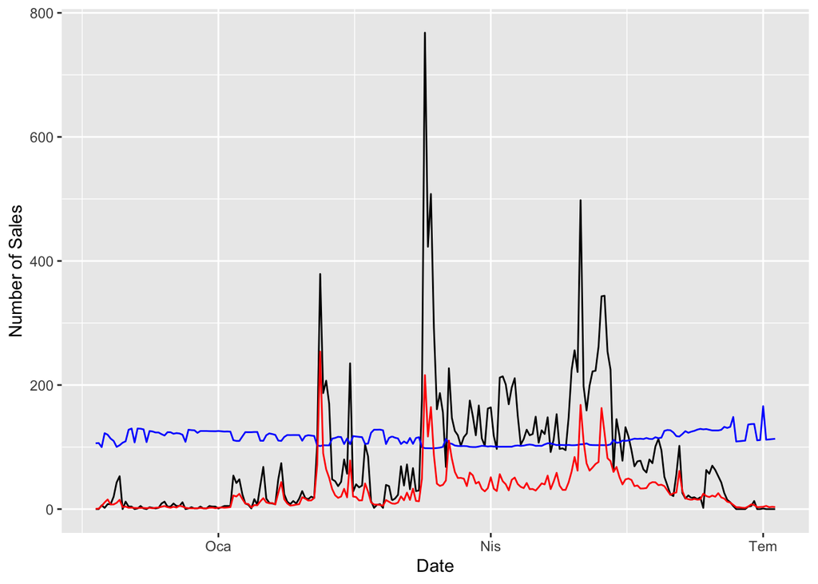

*Graph 3: Number of Sales over Time of Product 2* Auto-Correlation plot of the sales:

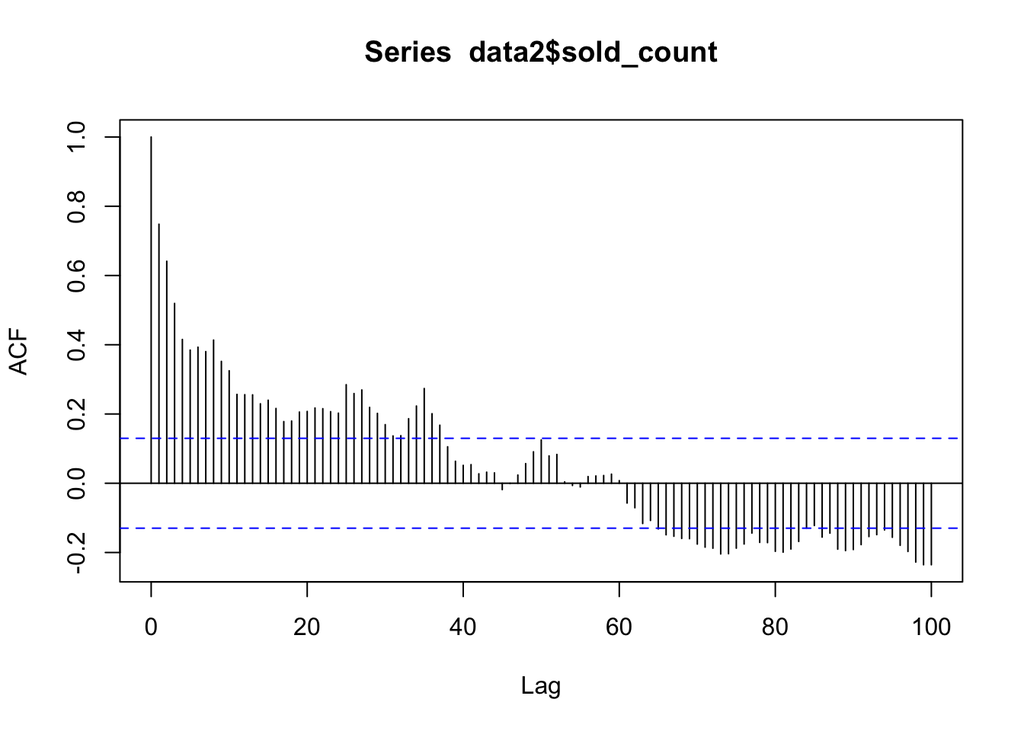

#### ARIMA Model

in the first step, we will found arima model as alternative model auto.arima and arima is used

Our first Arima model generated by auto.arima:

```
## Series: data2$sold_count
## ARIMA(0,1,4)
##
## Coefficients:
##           ma1      ma2      ma3      ma4
##       -0.4154  -0.0358  -0.1375  -0.1943
## s.e.   0.0653   0.0674   0.0688   0.0591
##
## sigma^2 estimated as 4302:  log likelihood=-1270.12
## AIC=2550.24   AICc=2550.51   BIC=2567.36
##
## Training set error measures:
##                      ME     RMSE     MAE  MPE MAPE      MASE       ACF1
## Training set 0.08233915 64.86914 30.9541 -Inf  Inf 0.9472337 0.01413899
```

Our second Arima model:

```
##
## Call:
## arima(x = data2$sold_count, order = c(3, 1, 2))
##
## Coefficients:
##          ar1      ar2      ar3      ma1     ma2
##       0.8499  -0.0027  -0.1360  -1.2452  0.3000
## s.e.  0.3123   0.1900   0.0756   0.3098  0.2903
##
## sigma^2 estimated as 4251:  log likelihood = -1270.78,  aic = 2553.55
##
## Training set error measures:
##                     ME     RMSE      MAE  MPE MAPE     MASE         ACF1
## Training set 0.1929087 65.05451 31.21553 -Inf  Inf 0.955234 -0.007546685
```

#### Linear Regression Model

We started with using every possible parameter in the linear model.

```
##
## Call:
## lm(formula = sold_count ~ visit_count + favored_count + category_sold +
##     basket_count + price + category_brand_sold + category_visits,
##     data = data2)
##
## Residuals:
##      Min       1Q   Median       3Q      Max
## -100.507  -15.228   -1.231    8.112   84.985
##
## Coefficients:
##                       Estimate Std. Error t value Pr(>|t|)
## (Intercept)          1.470e+02  2.313e+01   6.354 1.19e-09 ***
## visit_count          1.101e-02  3.159e-03   3.486 0.000591 ***
## favored_count       -1.323e-01  3.125e-02  -4.233 3.38e-05 ***
## category_sold       -1.285e-01  6.949e-02  -1.849 0.065849 .
## basket_count         1.391e-01  1.305e-02  10.659  < 2e-16 ***
## price               -1.196e+00  1.938e-01  -6.171 3.23e-09 ***
## category_brand_sold  1.121e-01  7.153e-02   1.567 0.118547
## category_visits      5.346e-04  7.570e-05   7.063 2.12e-11 ***
## ---
## Signif. codes:  0 '***' 0.001 '**' 0.01 '*' 0.05 '.' 0.1 ' ' 1
##
## Residual standard error: 24.57 on 220 degrees of freedom
## Multiple R-squared:  0.943,  Adjusted R-squared:  0.9411
## F-statistic: 519.5 on 7 and 220 DF,  p-value: < 2.2e-16
```

Akaike Information Criteria of the model:

```
## [1] 2116.865
```

After the first model, insignificant parameters will be eliminated one by one. And we add square values of the most significant attributes.

And our final linear model becomes:

```
##
## Call:
## lm(formula = sold_count ~ visit_count + I(visit_count^2) + favored_count +
##     category_sold + basket_count + price + I(price^2) + category_visits,
##     data = data2)
##
## Residuals:
##      Min       1Q   Median       3Q      Max
## -108.653  -11.350   -1.315   11.373   86.644
##
## Coefficients:
##                    Estimate Std. Error t value Pr(>|t|)
## (Intercept)       4.798e+02  1.390e+02   3.451 0.000669 ***
## visit_count       2.062e-02  3.236e-03   6.372 1.09e-09 ***
## I(visit_count^2) -2.703e-07  7.639e-08  -3.538 0.000492 ***
## favored_count    -1.713e-01  2.920e-02  -5.866 1.63e-08 ***
## category_sold    -1.819e-02  6.097e-03  -2.984 0.003164 **
## basket_count      1.291e-01  1.144e-02  11.289  < 2e-16 ***
## price            -7.267e+00  2.271e+00  -3.200 0.001576 **
## I(price^2)        2.687e-02  9.307e-03   2.888 0.004271 **
## category_visits   3.208e-04  7.392e-05   4.339 2.18e-05 ***
## ---
## Signif. codes:  0 '***' 0.001 '**' 0.01 '*' 0.05 '.' 0.1 ' ' 1
##
## Residual standard error: 23.48 on 219 degrees of freedom
## Multiple R-squared:  0.9482, Adjusted R-squared:  0.9463
## F-statistic: 500.7 on 8 and 219 DF,  p-value: < 2.2e-16
```

Akaike Information Criteria of the model:

```
## [1] 2097.018
```

#### Time Series Cross Validation:

We have 3 models and now we will run time series 50 days cross validation on our models.

Mean Absolute Error of our linear model:

```
## [1] 10.64039
```

Mean Absolute Error of our first ARIMA model:

```
## [1] 15.84191
```

Mean Absolute Error of our second ARIMA model:

```
## [1] 17.03687
```

## Product 3

#### Coat

This product is a coat and we expect it to have higher sale numbers in winter and autumn.

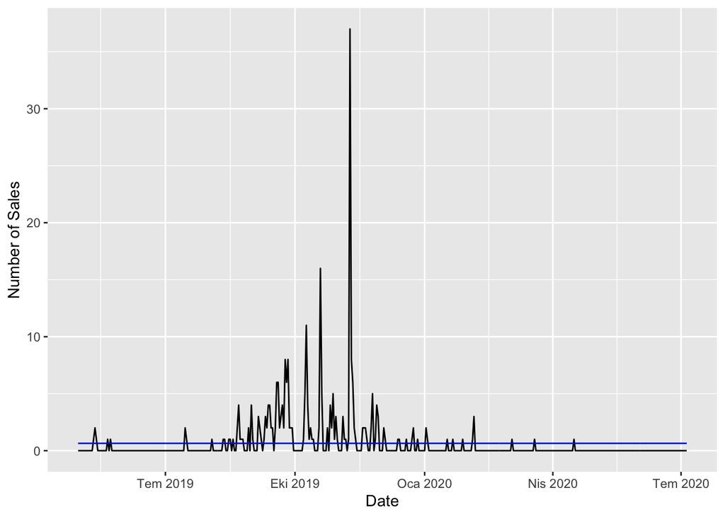

*Graph 6: Number of Sales over Time of Product 3*

The graph shows as we expected. Most of the sales are mainly between September and January. After February there is too few sales happened.

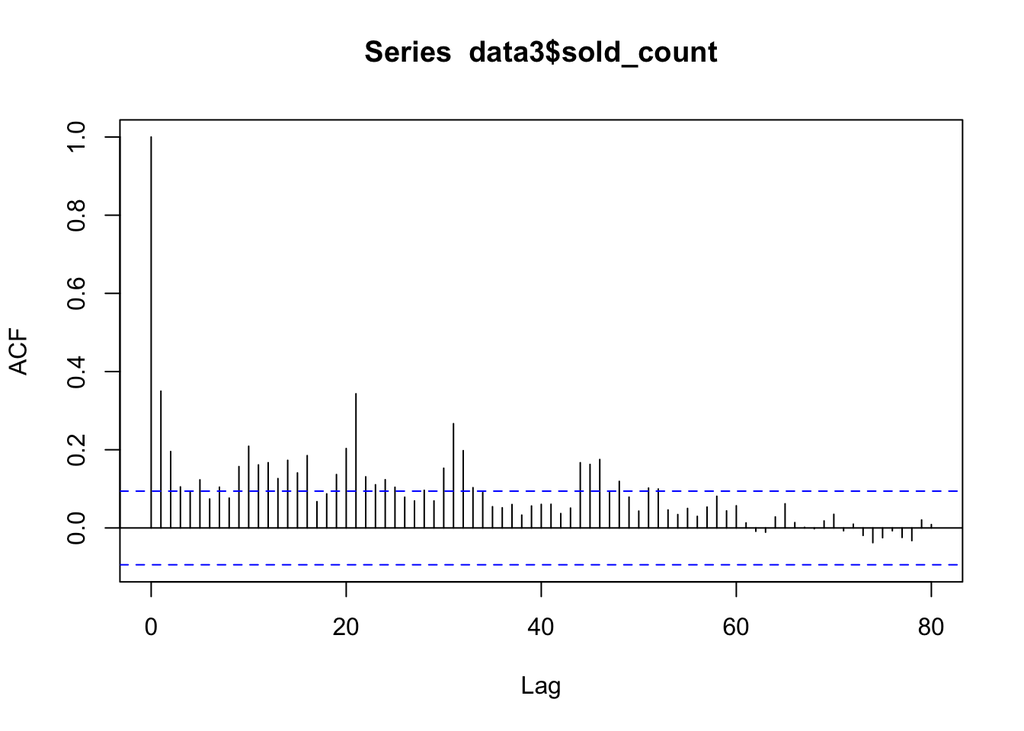

*Graph 7: Auto-Correlation Graph of the Number of Sales over Time of Product 3*

There seems no clear seasonality. The day before has a correlation.

So we add new columns which may be effective on building our model. These columns are: -1 and 2 day shifted numbers of sales -A binomial column specifing winter months -A binomial column specifing summer months

#### Linear Regression Model

We start with using every possible parameter in the model.

```
##
## Call:
## lm(formula = sold_count ~ price + visit_count + favored_count +
##     basket_count + category_sold + category_brand_sold + category_visits +
##     ty_visits + lag2 + lag1 + is_winter + is_summer, data = data3.2)
##
## Residuals:
##     Min      1Q  Median      3Q     Max
## -5.2636 -0.1922  0.0252  0.1841  6.7705
##
## Coefficients:
##                       Estimate Std. Error t value Pr(>|t|)
## (Intercept)         -5.941e-01  1.307e-01  -4.545 7.21e-06 ***
## price                7.944e-03  8.897e-04   8.929  < 2e-16 ***
## visit_count          3.873e-03  3.991e-04   9.705  < 2e-16 ***
## favored_count        6.659e-02  1.829e-02   3.642 0.000305 ***
## basket_count        -7.601e-02  5.514e-02  -1.378 0.168791
## category_sold        1.762e-04  1.507e-04   1.170 0.242834
## category_brand_sold  8.384e-04  1.461e-03   0.574 0.566436
## category_visits      3.697e-07  1.349e-07   2.741 0.006393 **
## ty_visits           -1.521e-09  1.603e-09  -0.949 0.343263
## lag2                -3.983e-02  1.913e-02  -2.082 0.037936 *
## lag1                -2.031e-02  2.013e-02  -1.009 0.313466
## is_winter           -5.565e-01  1.628e-01  -3.418 0.000692 ***
## is_summer            3.928e-01  1.148e-01   3.422 0.000683 ***
## ---
## Signif. codes:  0 '***' 0.001 '**' 0.01 '*' 0.05 '.' 0.1 ' ' 1
##
## Residual standard error: 0.8299 on 418 degrees of freedom
##   (2 observations deleted due to missingness)
## Multiple R-squared:  0.8769, Adjusted R-squared:  0.8733
## F-statistic: 248.1 on 12 and 418 DF,  p-value: < 2.2e-16
```

There seems to exist insignificant attributes.

Now we calculate the Akaike Information Criteria.

```
## [1] 1077.172
```

After several steps to eliminate the insignificant attributes, our final linear regression model is:

```
##
## Call:
## lm(formula = sold_count ~ price + visit_count + favored_count +
##     category_brand_sold + category_visits + lag1 + lag2 + is_winter +
##     is_summer, data = data3.2)
##
## Residuals:
##     Min      1Q  Median      3Q     Max
## -5.3450 -0.1919  0.0281  0.1695  6.7986
##
## Coefficients:
##                       Estimate Std. Error t value Pr(>|t|)
## (Intercept)         -6.180e-01  1.181e-01  -5.232 2.65e-07 ***
## price                8.052e-03  8.821e-04   9.128  < 2e-16 ***
## visit_count          3.915e-03  3.881e-04  10.088  < 2e-16 ***
## favored_count        6.587e-02  1.801e-02   3.657 0.000288 ***
## category_brand_sold  2.058e-03  9.757e-04   2.110 0.035467 *
## category_visits      2.323e-07  8.595e-08   2.702 0.007163 **
## lag1                -1.606e-02  1.990e-02  -0.807 0.420111
## lag2                -3.670e-02  1.899e-02  -1.933 0.053952 .
## is_winter           -3.952e-01  1.109e-01  -3.563 0.000408 ***
## is_summer            4.055e-01  1.143e-01   3.547 0.000434 ***
## ---
## Signif. codes:  0 '***' 0.001 '**' 0.01 '*' 0.05 '.' 0.1 ' ' 1
##
## Residual standard error: 0.83 on 421 degrees of freedom
##   (2 observations deleted due to missingness)
## Multiple R-squared:  0.876,  Adjusted R-squared:  0.8733
## F-statistic: 330.3 on 9 and 421 DF,  p-value: < 2.2e-16
```

We noticed that visit count has a high significance. So we add the square value of the visit count to the model and our final linear regression model is:

```
##
## Call:
## lm(formula = sold_count ~ price + visit_count + favored_count +
##     category_brand_sold + visit_sq + category_visits + lag2 +
##     lag1 + is_winter + is_summer, data = data3.2)
##
## Residuals:
##     Min      1Q  Median      3Q     Max
## -4.9253 -0.1927  0.0301  0.1551  7.4209
##
## Coefficients:
##                       Estimate Std. Error t value Pr(>|t|)
## (Intercept)         -4.926e-01  1.282e-01  -3.842 0.000141 ***
## price                8.808e-03  9.302e-04   9.469  < 2e-16 ***
## visit_count          2.611e-03  6.594e-04   3.960 8.80e-05 ***
## favored_count        8.355e-02  1.932e-02   4.324 1.91e-05 ***
## category_brand_sold  1.820e-03  9.749e-04   1.867 0.062652 .
## visit_sq             1.487e-07  6.100e-08   2.437 0.015204 *
## category_visits      2.060e-07  8.612e-08   2.392 0.017206 *
## lag2                -2.659e-02  1.933e-02  -1.375 0.169714
## lag1                 1.577e-02  2.370e-02   0.665 0.506176
## is_winter           -3.777e-01  1.105e-01  -3.418 0.000692 ***
## is_summer            3.054e-01  1.209e-01   2.527 0.011870 *
## ---
## Signif. codes:  0 '***' 0.001 '**' 0.01 '*' 0.05 '.' 0.1 ' ' 1
##
## Residual standard error: 0.8252 on 420 degrees of freedom
##   (2 observations deleted due to missingness)
## Multiple R-squared:  0.8777, Adjusted R-squared:  0.8748
## F-statistic: 301.4 on 10 and 420 DF,  p-value: < 2.2e-16
```

Now we calculate the Akaike Information Criteria.

```
## [1] 1070.338
```

It has a relatively high R^2 value of 0.88. AIC value is better than the initial model, we will move on with this model.

#### ARIMA model

We used 2 arima models, one by automated function auto.arima and one by trial.

The ARIMA model generated by auto.arima function:

```
## Series: (data3.2$sold_count)
## ARIMA(1,1,4)
##
## Coefficients:
##          ar1      ma1     ma2     ma3     ma4
##       0.8321  -1.5635  0.4543  0.0025  0.1202
## s.e.  0.1131   0.1187  0.1232  0.0968  0.0497
##
## sigma^2 estimated as 4.539:  log likelihood=-938.3
## AIC=1888.61   AICc=1888.81   BIC=1913.02
##
## Training set error measures:
##                        ME     RMSE       MAE MPE MAPE      MASE       ACF1
## Training set -0.002327853 2.115765 0.6779424 NaN  Inf 0.9633919 0.00135216
```

The ARIMA model built by us:

```
##
## Call:
## arima(x = data3.2$sold_count, order = c(0, 1, 1))
##
## Coefficients:
##           ma1
##       -0.9303
## s.e.   0.0184
##
## sigma^2 estimated as 4.793:  log likelihood = -952.49,  aic = 1908.97
##
## Training set error measures:
##                        ME     RMSE       MAE  MPE MAPE     MASE      ACF1
## Training set -0.002512627 2.186743 0.7359251 -Inf  Inf 1.045788 0.2135033
```

Now we have 3 different models. We will run a time series cross-validation with these models. The cross validation is going to be from 1 day to 50.

```r
MAE_vec3.1 <- c()
MAE_vec3.2 <- c()
MAE_vec3.3 <- c()

for(i in 1:50){
  data3_train <- data3.2[1:(.N-i)]
  data3_test <-  data3.2[(.N-i+1):.N]

  model3.1 <- auto.arima((data3_train$sold_count))
  model3.2 <- arima(data3_train$sold_count,c(0,1,1))
  model3.3 <- lm(sold_count~price+visit_count+favored_count+category_brand_sold+visit_sq+category_visits+lag2+lag1+is_winter+is_summer ,data3_train)

  forecast1 <- forecast(model3.1,i)
  forecast2 <- forecast(model3.2,i)
  forecast3 <- predict(model3.3,data3_test)

  MAE3.1 <- mean(abs(forecast1$mean-data3_test$sold_count))
  MAE3.2 <- mean(abs(forecast2$mean-data3_test$sold_count))
  MAE3.3 <- mean(abs(forecast3-data3_test$sold_count))

  MAE_vec3.1 <- c(MAE_vec3.1,MAE3.1)
  MAE_vec3.2 <- c(MAE_vec3.2,MAE3.2)
  MAE_vec3.3 <- c(MAE_vec3.3,MAE3.3)
}
```

Mean Absolute Error of ARIMA Model 1:

```
## [1] 0.007190842
```

Mean Absolute Error of ARIMA Model 2:

```
## [1] 0.002669151
```

Mean Absolute Error of Linear Model 1:

```
## [1] 0.1362408
```

It is clear that the model with lowest mean absolute error is our ARIMA (0,1,1) model found by our trials.

## Product 4

#### Step 2

Discount between the dates 2019-11-08-2019-11-13,iblack friday week and the first two days of corona are selected as outliers. Therefore,for the sales count of these days average of overall sales count is used. Also ’is_Covid’is created in order the explain the sales count after Corona.After taking mean for these outlier days the new Acf can seen in **figure 3**.The new plot can seen in **figure 4**.

#### Step 3

Trend is modelled by using linear regression approach.Visualization of trend can seen in **figure 5**. After removing trend from sold count acf is again calculated as seen in **figure 6** and there is still no repeating pattern in lags.So, seasonality becames not that much significant for this data.Therefore, modelling the sold count for this product linear approach will be used.

#### Figures

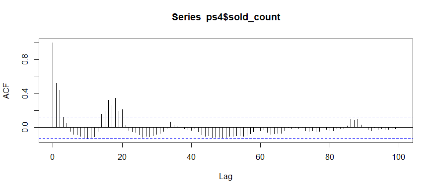

Graph 8: Acf of sold count

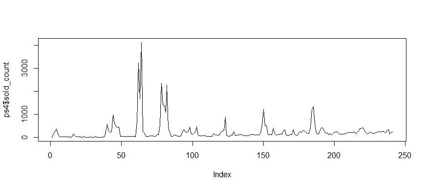

Graph 9:Plot of sold count

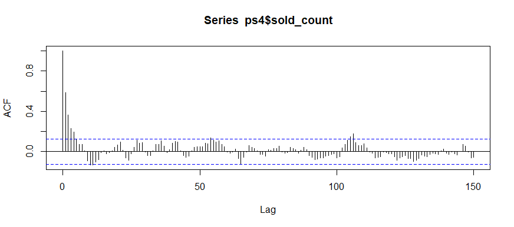

Graph 10: Acf of sold count after outliers removed

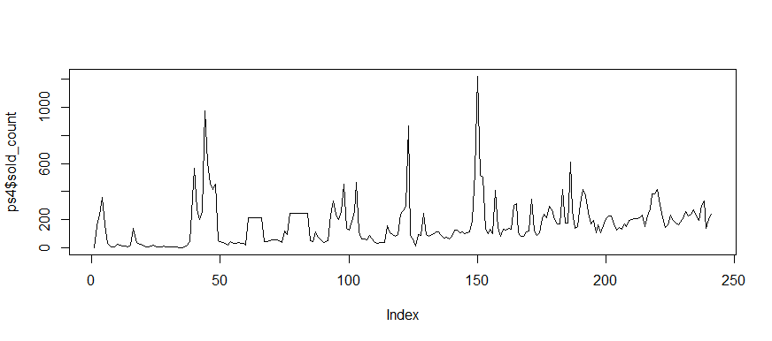

Graph 11: Plot of sold count after outliers removed

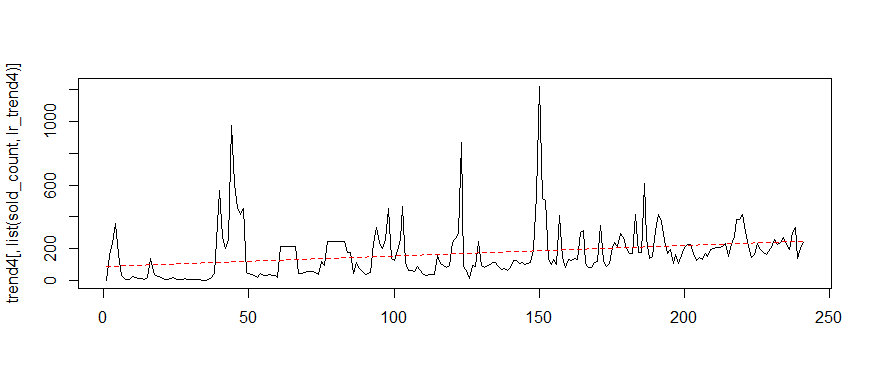

Graph 12: Visualization of trend

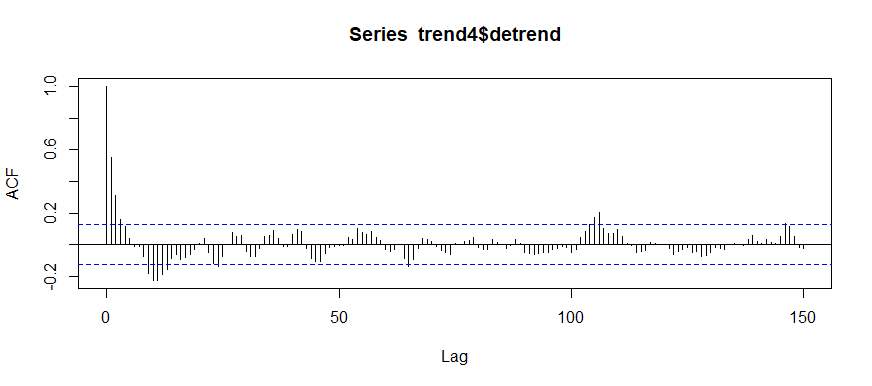

Graph 13: Acf after removing trend

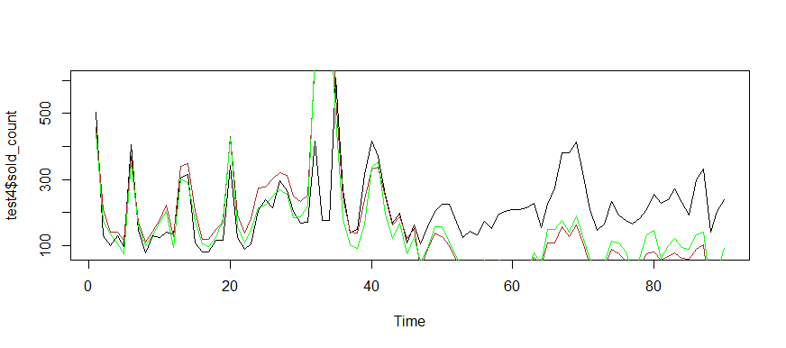

Graph 14: Visualizations of forecasts

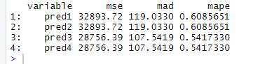

Graph 15: Error calculations of forecasts

#### codes for figures

##### Code for Figure 1

```r
acf(ps4$sold_count,lag.max=100)
```

##### Code for Figure 2

```r
plot(ps4$sold_count,type="l")
```

##### Code for Figure 3

```r
acf(ps4$sold_count,lag.max=150)
```

##### Code for Figure 4

```r
plot(ps4$sold_count,type="l")
```

##### Code for Figure 5

```r
matplot(trend4[,list(sold_count,lr_trend4)],type="l")
```

##### Code for Figure 6

```r
acf(trend4$detrend,lag.max=150)
```

##### Code for Figure 7

```r
ts.plot(test4$sold_count) #visualization of predictions and real values
lines(test4$pred1,col="blue")
lines(test4$pred2,col="brown")
lines(test4$pred3,col="orange")
lines(test4$pred4,col="green")
```

##### Code for Figure 8

```r
res=res[,list(mse=mean(se,na.rm=TRUE),mad=mean(ad,na.rm=TRUE),mape=mean(ape,na.rm=TRUE)),by=list(variable)]
```

#### Code for product 4

```r
library(data.table)
library(forecast)
install.packages("data.table") #install the required packages
install.packages("forecast")

data=fread("C:/Users/LENOVO/Desktop/challenge.csv",header=TRUE) #read the data
str(data)



4066298
content.id= 4066298 #id for the product


data4 <- data[product_content_id == "4066298"]
data4<-as.data.table(data4)
# converting order of the date from past to future
p4<-data4[rev(order(as.Date(data4$event_date, format="%d/%m/%Y"))),]
# the product has been selling since 2019-09-09
ps4<-p4[133:373,]
acf(ps4$sold_count,lag.max=100) #?t is a daily data and there is only significant increade in lag 16 and 18 the rest looks unsignificant  on
plot(ps4$sold_count,type="l")



#black friday unordinary sold count
ps4$sold_count[77:84] <-  mean(ps4$sold_count,na.rm = T)
acf(ps4$sold_count,lag.max=150)
plot(ps4$sold_count,type="l")

#discount unordinary sales
ps4$sold_count[61:66] <-  mean(ps4$sold_count,na.rm = T)
acf(ps4$sold_count,lag.max=150)
plot(ps4$sold_count,type="l")

#first two days of corona because it increase almost 4 times compare two one day before
ps4$sold_count[184:185] <-  mean(ps4$sold_count,na.rm = T)
acf(ps4$sold_count,lag.max=150)
plot(ps4$sold_count,type="l")

#effects of covid
ps4[,'is_Covid':= {
  if (as.Date(event_date)>as.Date("2020-03-10") ) 1
  else    0                  }
  ,by = event_date]


#Due to the fact that there was no repeating pattern in acf lags seasonal effects seem insignificant
#there might be trend so I modelled trend

trend4=ps4[,list(event_date,sold_count)]
trend4[,index:=1:.N]
ltrend4<-lm(sold_count~index,trend4) #good r squared
summary(ltrend4)
ltrend4<-ltrend4$fitted
trend4[,lr_trend4:=ltrend4]
matplot(trend4[,list(sold_count,lr_trend4)],type="l") #good visualization of linear trend
ps4[,trend:=trend4$lr_trend4]


trend4[,detrend:=sold_count-lr_trend4]
plot(trend4$detrend,type='l')
acf(trend4$detrend,lag.max=150) #after removing trend  still no repeating pattern in lags


fit=lm(sold_count~price + visit_count + favored_count
        + basket_count + category_sold + category_brand_sold+trend ,
        data=ps4)
summary(fit)
checkresiduals(fit)
AIC(fit)
#r squared g?zel ??kt?
fit2=lm(sold_count~price + visit_count + favored_count
       + basket_count+trend ,
       data=ps4)
summary(fit2)
checkresiduals(fit2)
AIC(fit2)

vsq<-ps4[,"visitsq" := visit_count^2]
fsq<-ps4[,"favoredsq" := favored_count^2]

fit3=lm(sold_count~ visit_count+ visitsq + favored_count+favoredsq+basket_count+category_sold+category_brand_sold +price+trend ,data=ps4)
summary(fit3)
checkresiduals(fit3)
AIC(fit3)

fit4=lm(sold_count~ visit_count+ visitsq  + favored_count+favoredsq+basket_count+category_sold+category_brand_sold +price+trend+is_Covid ,data=ps4)
summary(fit4)
checkresiduals(fit4)
AIC(fit4)

for(i in 1:90){

  train4 <- ps4[1:(.N-i)]
  test4 <-  ps4[(.N-i+1):.N]


  model1 <- lm(sold_count~price + visit_count + favored_count
               + basket_count+trend ,
               data=train4)
  model2<-lm(sold_count~price + visit_count + favored_count
             + basket_count+trend ,
             data=train4)
  model3<-lm(sold_count~ visit_count+ visitsq + favored_count+favoredsq+basket_count+category_sold+category_brand_sold +price+trend ,data=train4)
  model4<-lm(sold_count~ visit_count+ visitsq  + favored_count+favoredsq+basket_count+category_sold+category_brand_sold +price+trend+is_Covid ,data=train4)

  forecast1<- predict(model1,test4)
  forecast2<- predict(model2,test4)
  forecast3<- predict(model3,test4)
  forecast4<-predict(model4,test4)


}



test4[,pred1:=forecast1]
test4[,pred2:=forecast2]
test4[,pred3:=forecast3]
test4[,pred4:=forecast4]
ts.plot(test4$sold_count) #visualization of predictions and real values
lines(test4$pred1,col="blue")
lines(test4$pred2,col="brown")
lines(test4$pred3,col="orange")
lines(test4$pred4,col="green")
predtable=test4[,.(event_date,sold_count,pred1,pred2,pred3,pred4)]
melted=melt(predtable,id.vars=c(1,2),na.rm=TRUE)
res=melted[,list(se=(value-sold_count)^2,
                   ad=abs(value-sold_count),
                   ape=abs(value-sold_count)/sold_count,sold_count),by=list(event_date,variable)]

res=res[,list(mse=mean(se,na.rm=TRUE),mad=mean(ad,na.rm=TRUE),mape=mean(ape,na.rm=TRUE)),by=list(variable)]
res


#forecast 4 is the best one according to mape
```

## Product 5

#### Bikini Top

Beachwear products have higher sales numbers in summer, especially in the beginning of the summer.

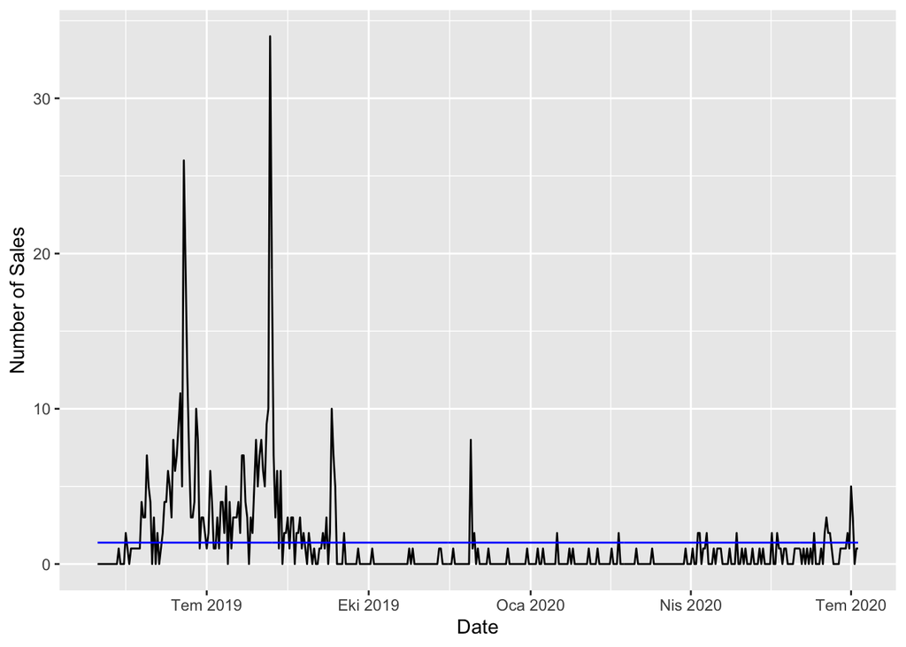

*Graph 16: Number of Sales over Time of Product 5*

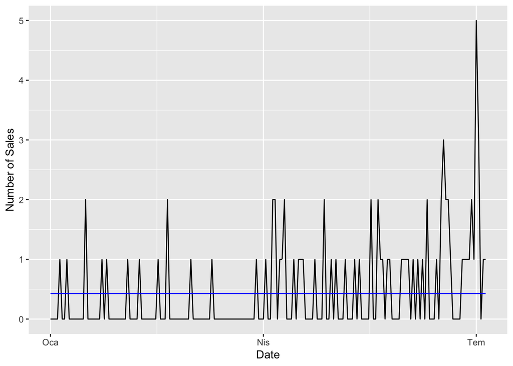

```r
data5_2020 <-  data5[event_date> "2019-12-31"]
ggplot(data5_2020,aes(event_date,sold_count)) + geom_line() + xlab("Date") + ylab("Number of Sales") + geom_line(aes(event_date,mean(data5_2020$sold_count)),color = "blue")
```

*Graph 17: Number of Sales in 2020 over Time of Product 5*

#### Linear Regression Model

We add one new column to our data. This column is specifying the summer months and months close to summer. Than we used every possible attribute at the initial model.

Our initial model:

```
##
## Call:
## lm(formula = sold_count ~ is_summer + price + visit_count + favored_count +
##     basket_count + category_sold + category_brand_sold + category_visits,
##     data = data5_2020)
##
## Residuals:
##      Min       1Q   Median       3Q      Max
## -1.07899 -0.15410  0.01060  0.08996  2.46275
##
## Coefficients:
##                       Estimate Std. Error t value Pr(>|t|)
## (Intercept)          3.483e+00  1.984e-01  17.551  < 2e-16 ***
## is_summer           -2.020e-02  9.960e-02  -0.203 0.839518
## price               -8.760e-02  5.052e-03 -17.338  < 2e-16 ***
## visit_count         -9.966e-04  3.797e-04  -2.624 0.009437 **
## favored_count        3.588e-02  1.241e-02   2.891 0.004317 **
## basket_count         4.149e-02  1.060e-02   3.916 0.000128 ***
## category_sold        8.950e-04  1.771e-04   5.053 1.07e-06 ***
## category_brand_sold -5.901e-04  1.884e-04  -3.132 0.002031 **
## category_visits     -2.136e-06  4.987e-07  -4.284 3.00e-05 ***
## ---
## Signif. codes:  0 '***' 0.001 '**' 0.01 '*' 0.05 '.' 0.1 ' ' 1
##
## Residual standard error: 0.3518 on 178 degrees of freedom
## Multiple R-squared:  0.7877, Adjusted R-squared:  0.7781
## F-statistic: 82.53 on 8 and 178 DF,  p-value: < 2.2e-16
```

Akaike Information criteria :

```
## [1] 150.7948
```

```
##
## Call:
## lm(formula = sold_count ~ is_summer + I(visit_count^2) + price +
##     visit_count + favored_count + visit_count:category_visits,
##     data = data5_2020)
##
## Residuals:
##      Min       1Q   Median       3Q      Max
## -1.01354 -0.14351  0.01274  0.08654  3.15426
##
## Coefficients:
##                               Estimate Std. Error t value Pr(>|t|)
## (Intercept)                  3.506e+00  2.116e-01  16.568  < 2e-16 ***
## is_summer                    3.392e-02  8.800e-02   0.385 0.700327
## I(visit_count^2)            -4.175e-07  2.588e-07  -1.613 0.108477
## price                       -9.056e-02  5.411e-03 -16.736  < 2e-16 ***
## visit_count                 -5.849e-04  6.063e-04  -0.965 0.336007
## favored_count                4.882e-02  1.357e-02   3.598 0.000414 ***
## visit_count:category_visits  8.623e-10  6.051e-10   1.425 0.155823
## ---
## Signif. codes:  0 '***' 0.001 '**' 0.01 '*' 0.05 '.' 0.1 ' ' 1
##
## Residual standard error: 0.3855 on 180 degrees of freedom
## Multiple R-squared:  0.7422, Adjusted R-squared:  0.7336
## F-statistic: 86.38 on 6 and 180 DF,  p-value: < 2.2e-16
```

Akaike Information criteria :

```
## [1] 183.0614
```

#### ARIMA Model

In our ARIMA models we used the original dataset. We built two models by trail and auto.arima.

#### Time Series Cross Validation

Now we have 3 different models. We will run a time series cross-validation with these models. The cross validation is going to be from 1 day to 50.

Mean Absolute Error of our linear model:

```
## [1] 1.164165
```

Mean Absolute Error of our first ARIMA model:

```
## [1] 0.814231
```

Mean Absolute Error of our second ARIMA model:

```
## [1] 0.8799065
```

## Product 6

#### Bluetooth Earphones

In this kind of technological products we expect to have sales numbers without seasonality. We expect to see an effect of price.

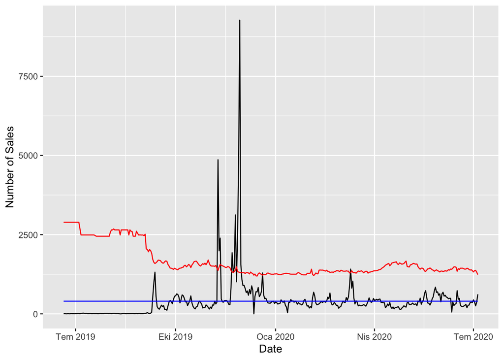

*Graph 18: Number of Sales over Time of Product 6*

There seems no seasonality as we expected. But the price (shown with red with scale of *10) seems have no clear effect. This can be caused by a strategy of the company to raise the prices some time before the sales days.

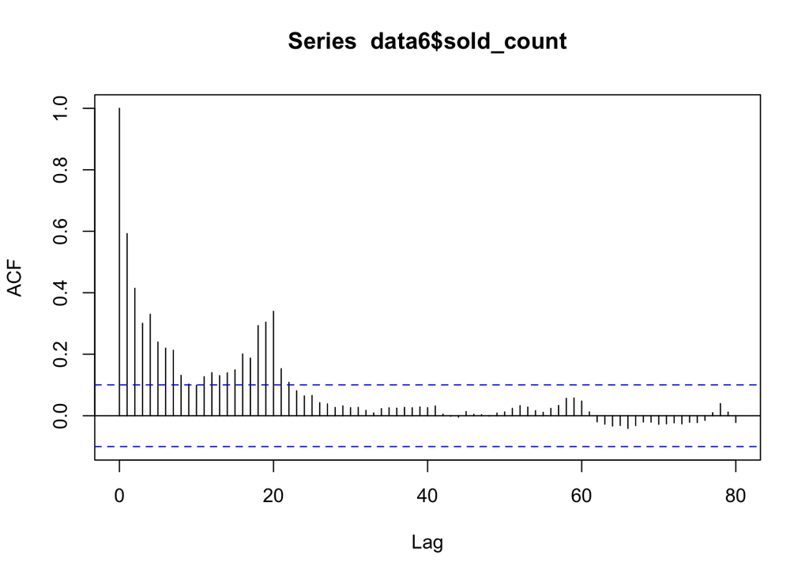

There is a correlation between following days. Also there is a correlation at around lag = 20 days but there is no seasonality detected.

The Black Friday effect is obvious on the graph at november. So we are going to smooth the data on these days.

```r
data6.2 <- data6
Mean_correction <-  mean(data6.2$sold_count[100:200])
data6.2$sold_count[140:170] <- Mean_correction
```

Before building our models, we assume some indicators which may effects over the sales. These are the previous price value, sales number of 2 and 7 days before, binary columns detecting the beginning time of schools, whether there is a sale, the time during CoViD-19 Pandemics.

Headphones are expected to have higher sales number sale time and the technology products sale discount is about 2.5%.

Because of the covid-19 people doing sports at home by using bluetooth headphones; covid-19 is created as a dummy variable.

#### Linear Regression Model

We built two models on two different datasets, the original data and the smoothened data.

We start with using every possible parameter in the model.

```
##
## Call:
## lm(formula = sold_count ~ price + sold_count + visit_count +
##     favored_count + basket_count + category_sold + category_brand_sold +
##     category_visits + ty_visits + previous_price + is_school_starts +
##     is_sales + is_Covid + lag2_sold + lag7_sold, data = data6)
##
## Residuals:
##      Min       1Q   Median       3Q      Max
## -1370.24   -70.09     2.76    81.56  2908.47
##
## Coefficients:
##                       Estimate Std. Error t value Pr(>|t|)
## (Intercept)         -7.127e+02  9.172e+01  -7.771 8.25e-14 ***
## price                2.566e+00  3.253e+00   0.789 0.430749
## visit_count          4.012e-02  1.655e-03  24.246  < 2e-16 ***
## favored_count       -3.368e-01  6.557e-02  -5.136 4.60e-07 ***
## basket_count         7.906e-03  2.753e-02   0.287 0.774159
## category_sold        2.092e-02  3.498e-02   0.598 0.550142
## category_brand_sold  4.924e-01  1.795e-01   2.743 0.006402 **
## category_visits     -1.458e-03  3.978e-04  -3.664 0.000285 ***
## ty_visits            1.271e-06  1.139e-06   1.116 0.265306
## previous_price      -7.867e-02  3.206e+00  -0.025 0.980435
## is_school_starts     2.722e+02  4.487e+01   6.065 3.34e-09 ***
## is_sales            -9.865e+01  6.079e+01  -1.623 0.105512
## is_Covid             1.896e+02  6.384e+01   2.970 0.003176 **
## lag2_sold           -3.436e-02  2.526e-02  -1.360 0.174623
## lag7_sold            1.715e-03  2.338e-02   0.073 0.941589
## ---
## Signif. codes:  0 '***' 0.001 '**' 0.01 '*' 0.05 '.' 0.1 ' ' 1
##
## Residual standard error: 272.1 on 360 degrees of freedom
##   (7 observations deleted due to missingness)
## Multiple R-squared:  0.8389, Adjusted R-squared:  0.8326
## F-statistic: 133.9 on 14 and 360 DF,  p-value: < 2.2e-16
```

There seems to exist insignificant attributes.

Now we calculate the Akaike Information Criteria.

```
## [1] 5285.558
```

After several steps to eliminate the insignificant attributes, our final linear regression model is:

```
##
## Call:
## lm(formula = sold_count ~ price + sold_count + favored_count +
##     category_brand_sold + category_visits + is_school_starts +
##     is_sales + visit_count + lag7_sold, data = data6)
##
## Residuals:
##      Min       1Q   Median       3Q      Max
## -1313.50   -75.82     8.63    94.23  3106.16
##
## Coefficients:
##                       Estimate Std. Error t value Pr(>|t|)
## (Intercept)         -6.849e+02  9.159e+01  -7.479 5.61e-13 ***
## price                2.423e+00  4.129e-01   5.867 9.91e-09 ***
## favored_count       -2.616e-01  6.297e-02  -4.155 4.05e-05 ***
## category_brand_sold  5.414e-01  9.583e-02   5.650 3.23e-08 ***
## category_visits     -5.417e-04  1.470e-04  -3.684 0.000265 ***
## is_school_starts     2.499e+02  4.518e+01   5.531 6.07e-08 ***
## is_sales            -1.102e+02  5.359e+01  -2.057 0.040356 *
## visit_count          3.772e-02  1.505e-03  25.061  < 2e-16 ***
## lag7_sold            4.956e-03  2.366e-02   0.209 0.834188
## ---
## Signif. codes:  0 '***' 0.001 '**' 0.01 '*' 0.05 '.' 0.1 ' ' 1
##
## Residual standard error: 277.5 on 366 degrees of freedom
##   (7 observations deleted due to missingness)
## Multiple R-squared:  0.8296, Adjusted R-squared:  0.8259
## F-statistic: 222.8 on 8 and 366 DF,  p-value: < 2.2e-16
```

We noticed that category_brand_sold, visit_count, favored_count has a high significance. So we add the square value of the attributes to the model and our final linear regression model is:

```
##
## Call:
## lm(formula = sold_count ~ price + sold_count + favored_count +
##     category_visits + is_school_starts + is_sales + sq_cat_br_sold +
##     lag7_sold + sq_visit + sq_favor, data = data6)
##
## Residuals:
##      Min       1Q   Median       3Q      Max
## -1660.39   -52.89    -1.82    48.66  1212.12
##
## Coefficients:
##                    Estimate Std. Error t value Pr(>|t|)
## (Intercept)       2.870e+02  6.084e+01   4.718 3.40e-06 ***
## price            -1.225e+00  2.673e-01  -4.583 6.32e-06 ***
## favored_count     5.334e-01  5.474e-02   9.744  < 2e-16 ***
## category_visits  -1.975e-04  8.872e-05  -2.226   0.0266 *
## is_school_starts  5.245e+01  2.813e+01   1.865   0.0630 .
## is_sales         -6.425e+01  3.475e+01  -1.849   0.0653 .
## sq_cat_br_sold    4.402e-04  7.628e-05   5.771 1.68e-08 ***
## lag7_sold         1.911e-02  1.526e-02   1.252   0.2114
## sq_visit          2.397e-07  5.569e-09  43.038  < 2e-16 ***
## sq_favor         -2.060e-04  1.008e-05 -20.440  < 2e-16 ***
## ---
## Signif. codes:  0 '***' 0.001 '**' 0.01 '*' 0.05 '.' 0.1 ' ' 1
##
## Residual standard error: 180.2 on 365 degrees of freedom
##   (7 observations deleted due to missingness)
## Multiple R-squared:  0.9284, Adjusted R-squared:  0.9266
## F-statistic: 525.7 on 9 and 365 DF,  p-value: < 2.2e-16
```

Now we calculate the Akaike Information Criteria.

```
## [1] 4971.575
```

It has a relatively high R^2 value of 0.93. AIC value is better than the initial model, we will move on with this model.

After executing similar steps, our final linear model with the smoothened dataset is:

```
##
## Call:
## lm(formula = sold_count ~ sold_count + favored_count + sq_favor +
##     sq_basket_count + category_brand_sold + category_visits +
##     ty_visits + previous_price + is_sales + is_Covid + lag1_sold +
##     lag7_sold, data = data6.2)
##
## Residuals:
##     Min      1Q  Median      3Q     Max
## -507.21  -40.07   -6.46   36.84  697.00
##
## Coefficients:
##                       Estimate Std. Error t value Pr(>|t|)
## (Intercept)          1.875e+02  4.467e+01   4.198 3.40e-05 ***
## favored_count        3.128e-01  2.972e-02  10.525  < 2e-16 ***
## sq_favor            -4.546e-05  5.723e-06  -7.943 2.50e-14 ***
## sq_basket_count      1.536e-05  1.802e-06   8.528 4.09e-16 ***
## category_brand_sold  2.522e-01  4.031e-02   6.258 1.10e-09 ***
## category_visits     -3.784e-04  1.296e-04  -2.920  0.00371 **
## ty_visits            9.646e-07  4.234e-07   2.278  0.02330 *
## previous_price      -7.608e-01  1.901e-01  -4.002 7.62e-05 ***
## is_sales            -6.107e+01  1.964e+01  -3.109  0.00203 **
## is_Covid            -1.003e+02  2.359e+01  -4.252 2.69e-05 ***
## lag1_sold            5.000e-01  3.411e-02  14.658  < 2e-16 ***
## lag7_sold            5.886e-02  2.922e-02   2.014  0.04471 *
## ---
## Signif. codes:  0 '***' 0.001 '**' 0.01 '*' 0.05 '.' 0.1 ' ' 1
##
## Residual standard error: 101.5 on 363 degrees of freedom
##   (7 observations deleted due to missingness)
## Multiple R-squared:  0.8463, Adjusted R-squared:  0.8416
## F-statistic: 181.7 on 11 and 363 DF,  p-value: < 2.2e-16
```

Now we calculate the Akaike Information Criteria.

```
## [1] 4542.769
```

#### ARIMA model

We used 2 arima models per datasets, one by automated function auto.arima and one by trial.

#### Time Series Cross Validation

Now we have 6 different models. We will run a time series cross-validation with these models. The cross validation is going to be from 1 day to 50.

Mean Absolute Error of Linear Model 1:

```
## [1] 51.38406
```

Mean Absolute Error of ARIMA Model 1:

```
## [1] 145.1824
```

Mean Absolute Error of ARIMA Model 2:

```
## [1] 139.1039
```

Mean Absolute Error of Linear Model 2:

```
## [1] 56.77141
```

Mean Absolute Error of ARIMA Model 3:

```
## [1] 143.6622
```

Mean Absolute Error of ARIMA Model 4:

```
## [1] 147.2049
```

It is clear that the model with lowest mean absolute error is our Linear model with the original dataset.

## Product 7

We start with filtering the data and removing the time where the product is not on the market. We also clean the price column. We plot the data.

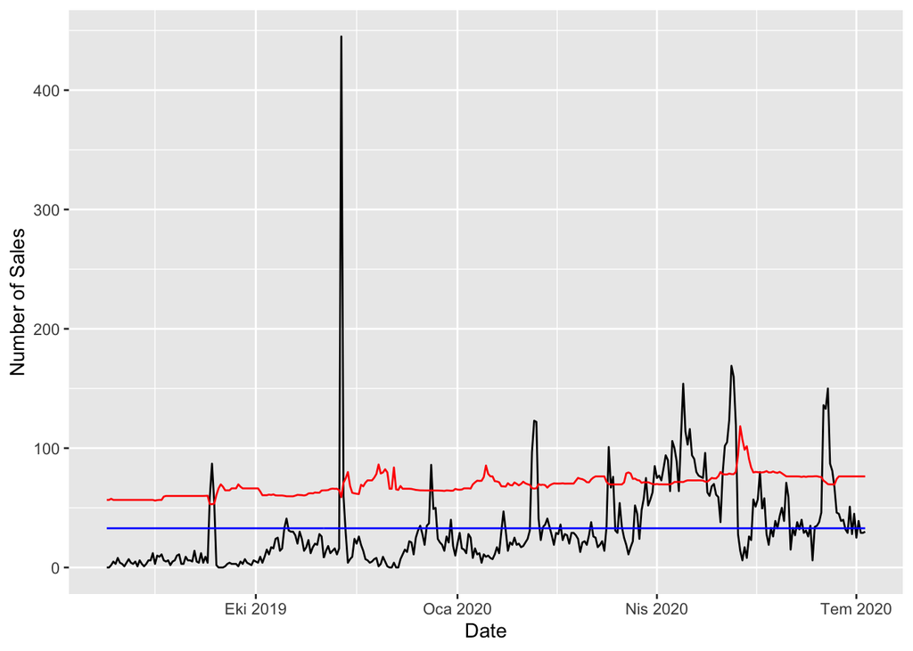

#### Linear Regression Model

We start with using every possible parameter in the model. Our initial model:

```
##
## Call:
## lm(formula = sold_count ~ price + visit_count + favored_count +
##     basket_count + category_sold + category_brand_sold + category_visits +
##     ty_visits, data = data7)
##
## Residuals:
##     Min      1Q  Median      3Q     Max
## -61.224  -6.290  -0.371   5.382  45.408
##
## Coefficients:
##                       Estimate Std. Error t value Pr(>|t|)
## (Intercept)          4.938e+01  7.839e+00   6.299 9.34e-10 ***
## price               -2.464e-01  4.320e-02  -5.704 2.56e-08 ***
## visit_count          1.494e-02  1.230e-03  12.146  < 2e-16 ***
## favored_count       -4.705e-02  2.076e-02  -2.267    0.024 *
## basket_count         7.516e-02  1.318e-02   5.704 2.56e-08 ***
## category_sold       -2.905e-02  1.837e-02  -1.581    0.115
## category_brand_sold  8.181e-02  5.403e-02   1.514    0.131
## category_visits     -7.789e-05  1.786e-05  -4.361 1.72e-05 ***
## ty_visits            1.891e-07  3.018e-08   6.266 1.13e-09 ***
## ---
## Signif. codes:  0 '***' 0.001 '**' 0.01 '*' 0.05 '.' 0.1 ' ' 1
##
## Residual standard error: 11.69 on 338 degrees of freedom
## Multiple R-squared:  0.9115, Adjusted R-squared:  0.9094
## F-statistic: 435.1 on 8 and 338 DF,  p-value: < 2.2e-16
```

Akaike Information Criteria of the model:

```
## [1] 2701.892
```

We move on with eliminating insignificant attributes and adding the squares of the most significant ones.

And our final linear model is:

```
##
## Call:
## lm(formula = sold_count ~ price + visit_count + basket_count +
##     I(visit_count^2) + category_visits + visit_count * basket_count,
##     data = data7)
##
## Residuals:
##     Min      1Q  Median      3Q     Max
## -34.392  -5.339  -0.633   4.545  50.107
##
## Coefficients:
##                            Estimate Std. Error t value Pr(>|t|)
## (Intercept)               3.092e+01  5.251e+00   5.888 9.38e-09 ***
## price                    -1.540e-01  2.694e-02  -5.716 2.39e-08 ***
## visit_count               1.075e-02  8.372e-04  12.843  < 2e-16 ***
## basket_count              2.678e-01  1.585e-02  16.897  < 2e-16 ***
## I(visit_count^2)          5.868e-08  2.575e-08   2.279   0.0233 *
## category_visits          -1.099e-04  1.501e-05  -7.322 1.78e-12 ***
## visit_count:basket_count -1.721e-05  1.512e-06 -11.382  < 2e-16 ***
## ---
## Signif. codes:  0 '***' 0.001 '**' 0.01 '*' 0.05 '.' 0.1 ' ' 1
##
## Residual standard error: 10.43 on 340 degrees of freedom
## Multiple R-squared:  0.9291, Adjusted R-squared:  0.9278
## F-statistic: 742.4 on 6 and 340 DF,  p-value: < 2.2e-16
```

Akaike Information Criteria of the model:

```
## [1] 2621.02
```

Adjusted r-square value is 0.9278, which is acceptable. AIC value has reduced significantly from the initial model.

All covariates significant

We checked possible nonlinear correlations

We accept the model as fine and move on with this model.

We run 10 fold cross validation to check its performance

```
## Linear Regression
##
## 347 samples
##   4 predictor
##
## No pre-processing
## Resampling: Cross-Validated (10 fold)
## Summary of sample sizes: 312, 313, 312, 314, 312, 312, ...
## Resampling results:
##
##   RMSE      Rsquared   MAE
##   26.14148  0.8595131  10.17578
##
## Tuning parameter 'intercept' was held constant at a value of TRUE
```

## Product 8

#### Purifying Foaming Gel

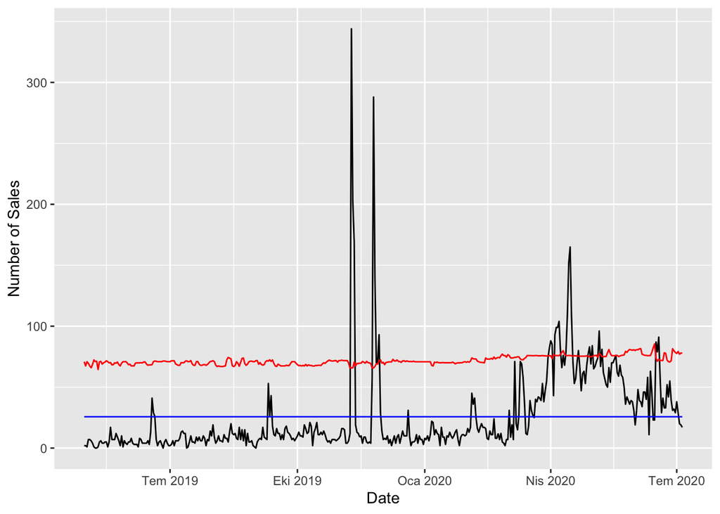

*Graph 16: Number of Sales over Time of Product 8*

The product seems to have a increased sales after March 2020 which corresponds to COVID-19 pandemics.

Auto-Correlation graph of the sales:

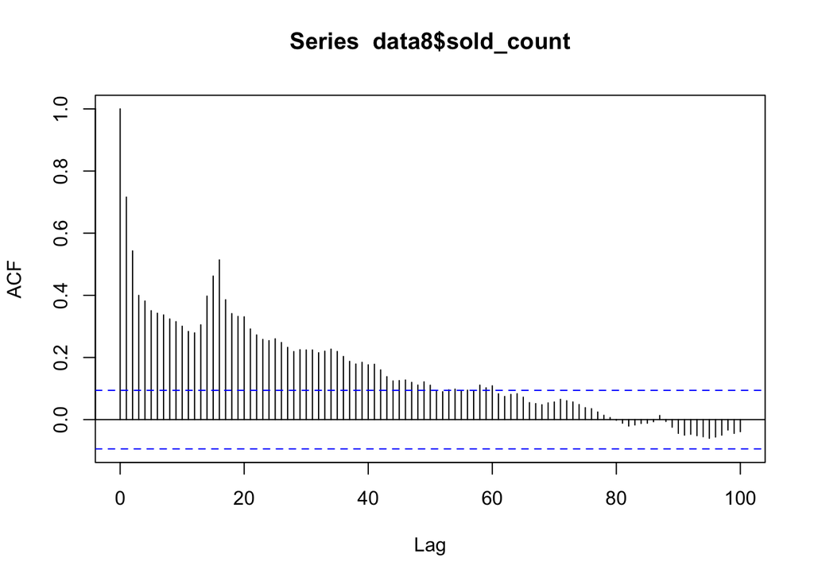

*Graph 17: Auto Correlation graph of Product 8*

Data has a correlation between neighboring days, there seems to exist a trend.

We start with using every possible parameter in the model.

```
##
## Call:
## lm(formula = sold_count ~ visit_count + favored_count + category_sold +
##     basket_count + price + category_brand_sold + category_visits,
##     data = data8)
##
## Residuals:
##      Min       1Q   Median       3Q      Max
## -181.268   -4.610   -1.057    3.670  111.149
##
## Coefficients:
##                       Estimate Std. Error t value Pr(>|t|)
## (Intercept)          9.759e+01  2.709e+01   3.603 0.000352 ***
## visit_count          3.257e-02  2.065e-03  15.773  < 2e-16 ***
## favored_count       -1.918e-02  1.890e-02  -1.015 0.310833
## category_sold        6.244e-03  2.469e-03   2.529 0.011790 *
## basket_count        -4.707e-02  2.212e-02  -2.128 0.033887 *
## price               -1.443e+00  3.861e-01  -3.736 0.000212 ***
## category_brand_sold -4.178e-02  2.096e-02  -1.993 0.046859 *
## category_visits     -1.410e-05  2.516e-05  -0.560 0.575640
## ---
## Signif. codes:  0 '***' 0.001 '**' 0.01 '*' 0.05 '.' 0.1 ' ' 1
##
## Residual standard error: 16.85 on 425 degrees of freedom
## Multiple R-squared:  0.7734, Adjusted R-squared:  0.7696
## F-statistic: 207.2 on 7 and 425 DF,  p-value: < 2.2e-16
```

There seems to exist insignificant attributes.

Now we calculate the Akaike Information Criteria.

```
## [1] 3684.778
```

After several steps to eliminate the insignificant attributes, our final linear regression model is:

```
##
## Call:
## lm(formula = sold_count ~ visit_count + is_Covid + I(visit_count^2) +
##     basket_count + price, data = data8)
##
## Residuals:
##     Min      1Q  Median      3Q     Max
## -85.247  -5.694   0.221   5.104  95.865
##
## Coefficients:
##                    Estimate Std. Error t value Pr(>|t|)
## (Intercept)       1.180e+02  2.355e+01   5.008 8.07e-07 ***
## visit_count       5.029e-02  2.277e-03  22.085  < 2e-16 ***
## is_Covid          3.117e+00  3.591e+00   0.868    0.386
## I(visit_count^2) -2.440e-06  2.556e-07  -9.548  < 2e-16 ***
## basket_count     -1.141e-01  1.298e-02  -8.792  < 2e-16 ***
## price            -1.849e+00  3.347e-01  -5.525 5.74e-08 ***
## ---
## Signif. codes:  0 '***' 0.001 '**' 0.01 '*' 0.05 '.' 0.1 ' ' 1
##
## Residual standard error: 15.2 on 427 degrees of freedom
## Multiple R-squared:  0.8148, Adjusted R-squared:  0.8126
## F-statistic: 375.7 on 5 and 427 DF,  p-value: < 2.2e-16
```

It has a relatively hig R^2 with 0.81.

Now we check its Akaike Information Criteria value.

```
## [1] 3593.397
```

#### ARIMA models

We have two ARIMA models one by auto.arima and the other by our trial.

```r
auto.arima(data8$sold_count)
```

```
## Series: data8$sold_count
## ARIMA(0,1,3)
##
## Coefficients:
##           ma1      ma2      ma3
##       -0.3601  -0.1996  -0.2957
## s.e.   0.0467   0.0469   0.0441
##
## sigma^2 estimated as 565.9:  log likelihood=-1981.15
## AIC=3970.31   AICc=3970.4   BIC=3986.58
```

```r
model8 <- arima(data8$sold_count,c(2,1,3))
```

#### Time Series Cross Validation

Now we have 3 different models. We will run a time series cross-validation with these models. The cross validation is going to be from 1 day to 50.

Mean Absolute Error of our linear model:

```
## [1] 11.05313
```

Mean Absolute Error of our first ARIMA model:

```
## [1] 22.08555
```

Mean Absolute Error of our second ARIMA model:

```
## [1] 21.89945
```

The best model with lowest MAE value is our linear model.